# HW3

Deepika Dilip, Tora Mullings, Daniel Sullivan, Deepa Sharma, Bikram Barua, Newman Okereafor

2022-10-19

# Data Exploration

## Correlation Plot

[output not shown]

[output cut: 919 more lines]

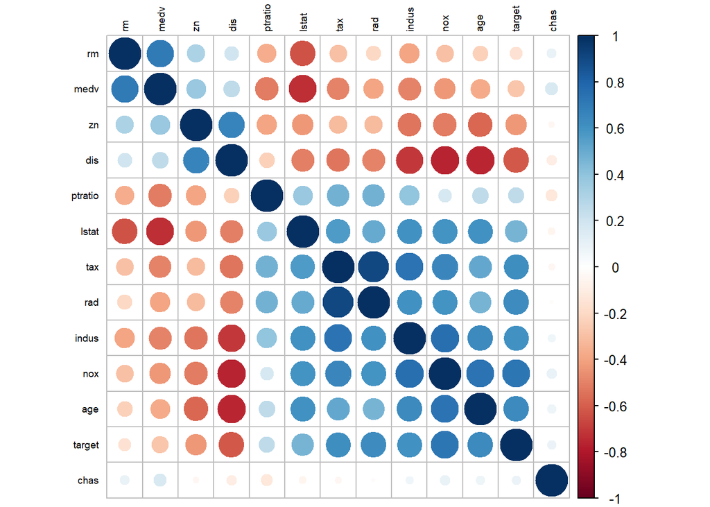

*Interpretation*: `tax` and `rad` are highliy correlated variables. Meanwhile `dis` is inversely correlated with `indus`, `nox`, and `age`.

## Distribution Visualization

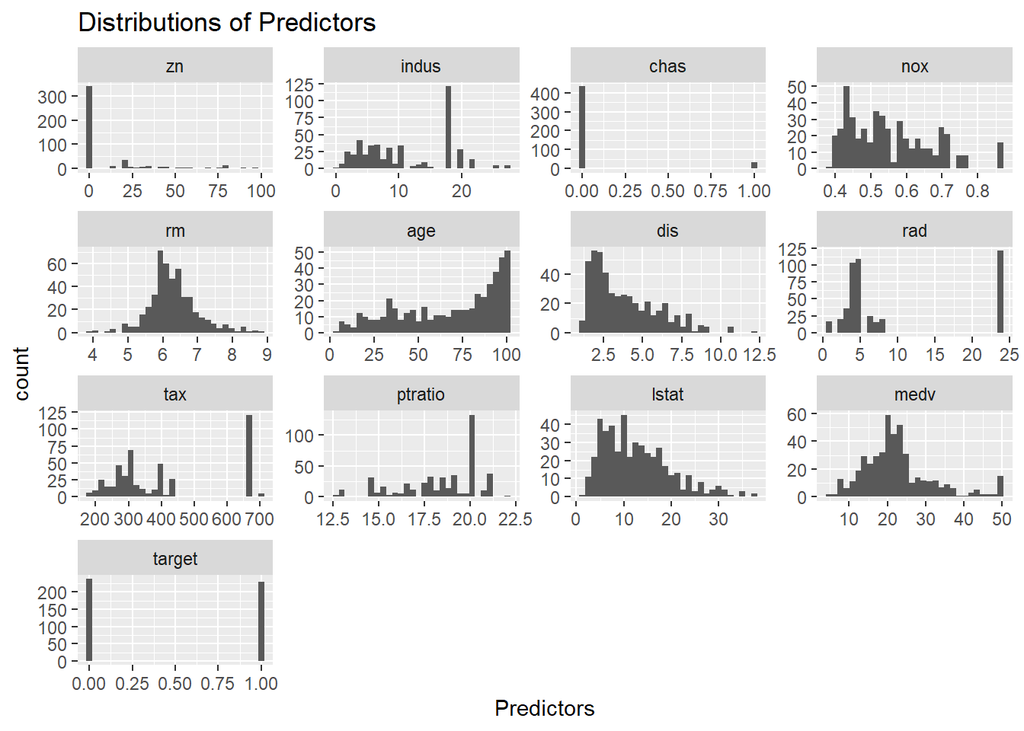

*Interpretation*: `target` is a binary variable (outcome). Age is skewed to the left. `rm` is normally distributed. `tax` and `rad` have a couple of outliers but its lower quadrant maintains a normal distribution.

## Building models

### Model 1: all predictors

```r
lmod <- glm(target ~ ., family = binomial, crime.train)
summary(lmod)
```

```
##
## Call:
## glm(formula = target ~ ., family = binomial, data = crime.train)
##
## Deviance Residuals:
##     Min       1Q   Median       3Q      Max
## -1.8464  -0.1445  -0.0017   0.0029   3.4665
##
## Coefficients:
##               Estimate Std. Error z value Pr(>|z|)
## (Intercept) -40.822934   6.632913  -6.155 7.53e-10 ***
## zn           -0.065946   0.034656  -1.903  0.05706 .
## indus        -0.064614   0.047622  -1.357  0.17485
## chas          0.910765   0.755546   1.205  0.22803
## nox          49.122297   7.931706   6.193 5.90e-10 ***
## rm           -0.587488   0.722847  -0.813  0.41637
## age           0.034189   0.013814   2.475  0.01333 *
## dis           0.738660   0.230275   3.208  0.00134 **
## rad           0.666366   0.163152   4.084 4.42e-05 ***
## tax          -0.006171   0.002955  -2.089  0.03674 *
## ptratio       0.402566   0.126627   3.179  0.00148 **
## lstat         0.045869   0.054049   0.849  0.39608
## medv          0.180824   0.068294   2.648  0.00810 **
## ---
## Signif. codes:  0 '***' 0.001 '**' 0.01 '*' 0.05 '.' 0.1 ' ' 1
##
## (Dispersion parameter for binomial family taken to be 1)
##
##     Null deviance: 645.88  on 465  degrees of freedom
## Residual deviance: 192.05  on 453  degrees of freedom
## AIC: 218.05
##
## Number of Fisher Scoring iterations: 9
```

### Model 2: Backward Elimination

```r
train.control <- trainControl(method="cv", number=10)   # k-fold cross-validation
step.model <- train(target ~., data=crime.train, method="leapBackward", tuneGrid=data.frame(nvmax=1:12), trControl=train.control)
step.model$results
```

```
##    nvmax      RMSE  Rsquared       MAE     RMSESD RsquaredSD      MAESD
## 1      1 0.3435138 0.5396922 0.2781774 0.03248588 0.09919977 0.03432656
## 2      2 0.3209021 0.5944799 0.2546189 0.03849772 0.10453011 0.03214635
## 3      3 0.3144094 0.6110223 0.2416950 0.04240676 0.11364987 0.03504028
## 4      4 0.3104006 0.6214713 0.2380148 0.04065908 0.10893013 0.03331782
## 5      5 0.3129269 0.6156857 0.2407960 0.03972419 0.10629287 0.03217443
## 6      6 0.3159736 0.6081820 0.2436589 0.04173007 0.11083972 0.03311376
## 7      7 0.3166553 0.6064802 0.2446351 0.04104859 0.10884576 0.03336681
## 8      8 0.3172138 0.6060023 0.2456824 0.04077343 0.10807817 0.03306922
## 9      9 0.3183834 0.6032370 0.2478203 0.04063516 0.10807366 0.03315036
## 10    10 0.3180108 0.6042376 0.2476614 0.04038322 0.10736200 0.03291434
## 11    11 0.3171049 0.6062781 0.2469890 0.04047593 0.10709034 0.03300936
## 12    12 0.3169894 0.6066125 0.2469415 0.04055098 0.10755923 0.03318227
```

The model with 4 predictors has the lowest RSME value. It also has the highest R-squared.

```r
summary(step.model$finalModel)
```

```
## Subset selection object
## 12 Variables  (and intercept)
##         Forced in Forced out
## zn          FALSE      FALSE
## indus       FALSE      FALSE
## chas        FALSE      FALSE
## nox         FALSE      FALSE
## rm          FALSE      FALSE
## age         FALSE      FALSE
## dis         FALSE      FALSE
## rad         FALSE      FALSE
## tax         FALSE      FALSE
## ptratio     FALSE      FALSE
## lstat       FALSE      FALSE
## medv        FALSE      FALSE
## 1 subsets of each size up to 4
## Selection Algorithm: backward
##          zn  indus chas nox rm  age dis rad tax ptratio lstat medv
## 1  ( 1 ) " " " "   " "  "*" " " " " " " " " " " " "     " "   " "
## 2  ( 1 ) " " " "   " "  "*" " " " " " " "*" " " " "     " "   " "
## 3  ( 1 ) " " " "   " "  "*" " " "*" " " "*" " " " "     " "   " "
## 4  ( 1 ) " " " "   " "  "*" " " "*" " " "*" " " " "     " "   "*"
```

```r
coef(step.model$finalModel, 4)
```

```
##  (Intercept)          nox          age          rad         medv
## -1.118239456  1.853194962  0.003720475  0.018598826  0.006675859
```

```r
lmod1 <- glm(target ~ nox + age + rad + medv, family = binomial, crime.train)
lmod1
```

```
##
## Call:  glm(formula = target ~ nox + age + rad + medv, family = binomial,
##     data = crime.train)
##
## Coefficients:
## (Intercept)          nox          age          rad         medv
##   -17.62627     23.62371      0.01824      0.45277      0.04481
##
## Degrees of Freedom: 465 Total (i.e. Null);  461 Residual
## Null Deviance:       645.9
## Residual Deviance: 232.8     AIC: 242.8
```

### Analysing Model 2

### Odds Ratio of Model 2

#### The odds ratio is to measure the association between independent variables and dependent variables in R. The model co-eefficients are identified using the ‘coef’ function.

#### The ‘conf-int’ argument inside the exponential function calculates the confidence interval for the odds ratio of the model. Then the estimates can be combined using ‘cbind’.

```r
coef(lmod1)
```

```
##  (Intercept)          nox          age          rad         medv
## -17.62627078  23.62370900   0.01824039   0.45277065   0.04480705
```

```r
exp(coef(lmod1))
```

```
##  (Intercept)          nox          age          rad         medv
## 2.213135e-08 1.818220e+10 1.018408e+00 1.572663e+00 1.045826e+00
```

```r
exp(confint(lmod1))
```

```
##                    2.5 %       97.5 %
## (Intercept) 2.251171e-10 1.140360e-06
## nox         1.239142e+07 6.557140e+13
## age         1.000502e+00 1.037309e+00
## rad         1.289641e+00 1.969665e+00
## medv        1.000694e+00 1.096061e+00
```

```r
cbind(coef(lmod1), odds_ratio = exp(coef(lmod1)), exp(confint(lmod1)))
```

```
##                            odds_ratio        2.5 %       97.5 %
## (Intercept) -17.62627078 2.213135e-08 2.251171e-10 1.140360e-06
## nox          23.62370900 1.818220e+10 1.239142e+07 6.557140e+13
## age           0.01824039 1.018408e+00 1.000502e+00 1.037309e+00
## rad           0.45277065 1.572663e+00 1.289641e+00 1.969665e+00
## medv          0.04480705 1.045826e+00 1.000694e+00 1.096061e+00
```

### Predicting Probability

#### The probability can be predicted of the model using the fitted function. The result can be rounded using the round function. The predicted values can be added as a new column in the dataset.

```r
crime.train$predict_prob <- round(fitted(lmod1), 2)
head(crime.train)
```

```
##   zn indus chas   nox    rm   age    dis rad tax ptratio lstat medv target
## 1  0 19.58    0 0.605 7.929  96.2 2.0459   5 403    14.7  3.70 50.0      1
## 2  0 19.58    1 0.871 5.403 100.0 1.3216   5 403    14.7 26.82 13.4      1
## 3  0 18.10    0 0.740 6.485 100.0 1.9784  24 666    20.2 18.85 15.4      1
## 4 30  4.93    0 0.428 6.393   7.8 7.0355   6 300    16.6  5.19 23.7      0
## 5  0  2.46    0 0.488 7.155  92.2 2.7006   3 193    17.8  4.82 37.9      0
## 6  0  8.56    0 0.520 6.781  71.3 2.8561   5 384    20.9  7.67 26.5      0
##   predict_prob
## 1         0.95
## 2         1.00
## 3         1.00
## 4         0.03
## 5         0.20
## 6         0.36
```

### Classification, Sensitivity and Specificity

```r
classification_table <- table(crime.train$target, crime.train$predict_prob > 0.5)
classification_table
```

```
##
##     FALSE TRUE
##   0   214   23
##   1    37  192
```

#### True indicates predicted ‘Targets’ and False indicates predicted ‘non Target’

#### There are 214 correctly predicted ‘non Target’ and 192 correctly predicted ‘Targets’.

#### There are 23 wrongly predicted as ‘Targets’ and 37 wrongly predicted as ‘Non Targets’.

```r
sensitivity <- (classification_table[2,2]/(classification_table[2,2] + classification_table[2,1])) * 100
sensitivity
```

```
## [1] 83.84279
```

```r
specificity <- (classification_table[1,1]/(classification_table[1,1] + classification_table[1,2])) * 100
specificity
```

```
## [1] 90.29536
```

#### The Sensitivity is 83.8% and Specificity is 90.2%, when the cuttoff is 0.5.

## calculate McFadden’s R2 in Model 1 and 2

we can compute a metric known as McFadden’s R2, which ranges from 0 to just under 1. In practice, values over 0.40 indicate that a model fits the data very well.

We can compute McFadden’s R2 for our model using the pR2 function from the pscl package:

#Model1

```r
pscl::pR2(lmod)["McFadden"]
```

```
## fitting null model for pseudo-r2
```

```
##  McFadden
## 0.7026566
```

# Model 2

```r
pscl::pR2(lmod1)["McFadden"]
```

```
## fitting null model for pseudo-r2
```

```
##  McFadden
## 0.6395641
```

A value of 0.6395641 is quite high for McFadden’s R2, which indicates that our model fits the data very well and has high predictive power.

## VIF Values:

```r
#calculate VIF values for each predictor variable in model1
car::vif(lmod)
```

```
##       zn    indus     chas      nox       rm      age      dis      rad
## 1.823146 2.682271 1.241479 4.160497 5.813851 2.569961 3.887981 1.942967
##      tax  ptratio    lstat     medv
## 2.144040 2.275557 2.642656 8.122037
```

```r
#calculate VIF values for each predictor variable in model2
car::vif(lmod1)
```

```
##      nox      age      rad     medv
## 1.562986 1.549970 1.114783 1.235393
```

## Model 3 - Forward Selection

```r
# Create an empty model with no variables
lmod3 <- glm(target ~ 1, data = crime.train, family = 'binomial')
logMod3 <- lmod3 %>%
  stepAIC(direction = "forward",
          scope = ~ zn + indus + chas + nox + rm + age + dis
                    + rad + tax + ptratio + lstat + medv,
          trace = FALSE)
summary(lmod3 )
```

```
##
## Call:
## glm(formula = target ~ 1, family = "binomial", data = crime.train)
##
## Deviance Residuals:
##    Min      1Q  Median      3Q     Max
## -1.163  -1.163  -1.163   1.192   1.192
##
## Coefficients:
##             Estimate Std. Error z value Pr(>|z|)
## (Intercept) -0.03434    0.09266  -0.371    0.711
##
## (Dispersion parameter for binomial family taken to be 1)
##
##     Null deviance: 645.88  on 465  degrees of freedom
## Residual deviance: 645.88  on 465  degrees of freedom
## AIC: 647.88
##
## Number of Fisher Scoring iterations: 3
```

## model 4 probit regression

#### Dan

After the automated elimination of variables for the model, we wanted to compair the probit and logit models.

```
##    nvmax      RMSE  Rsquared       MAE     RMSESD RsquaredSD      MAESD
## 1      1 0.2826364 0.6755106 0.1651006 0.05791670  0.1319576 0.04341838
## 2      2 0.2842034 0.6730298 0.1729584 0.05533767  0.1280238 0.04044685
## 3      3 0.2783151 0.6862168 0.1751490 0.05317428  0.1202604 0.03996492
## 4      4 0.2777799 0.6891899 0.1757882 0.05067062  0.1156936 0.03646739
## 5      5 0.2750100 0.6942544 0.1761114 0.05213588  0.1181516 0.03783903
## 6      6 0.2768730 0.6900848 0.1791447 0.05179793  0.1180296 0.03784509
## 7      7 0.2779293 0.6879988 0.1799941 0.05074816  0.1160329 0.03745663
## 8      8 0.2782743 0.6872240 0.1816977 0.05020459  0.1150111 0.03574489
## 9      9 0.2785589 0.6866819 0.1815924 0.04956483  0.1136452 0.03629058
## 10    10 0.2792091 0.6855264 0.1823060 0.04905463  0.1129431 0.03580818
## 11    11 0.2798555 0.6844358 0.1830280 0.04895047  0.1133417 0.03569625
## 12    12 0.2798221 0.6841176 0.1829485 0.04927708  0.1138343 0.03572653
```

```
##  (Intercept)          dis          rad          tax      ptratio predict_prob
## -0.440418102  0.027390434  0.008166783 -0.001009682  0.029656637  1.256772968
```

```
##
## Call:  glm(formula = target ~ nox + age + rad + medv, family = binomial(link = probit),
##     data = crime.train)
##
## Coefficients:
## (Intercept)          nox          age          rad         medv
##  -10.354373    14.158128     0.009217     0.264490     0.025630
##
## Degrees of Freedom: 465 Total (i.e. Null);  461 Residual
## Null Deviance:       645.9
## Residual Deviance: 230.9     AIC: 240.9
```

```
##
## Call:  glm(formula = target ~ dis + rad + tax + ptratio, family = binomial(link = probit),
##     data = crime.train)
##
## Coefficients:
## (Intercept)          dis          rad          tax      ptratio
##  -0.1323944   -0.4796467    0.3069465   -0.0009582    0.0216509
##
## Degrees of Freedom: 465 Total (i.e. Null);  461 Residual
## Null Deviance:       645.9
## Residual Deviance: 304.7     AIC: 314.7
```

### analyzing probit models

#### classification tables

Probit forward model

```
##
##     FALSE TRUE
##   0   204   33
##   1    38  191
```

probit backward model

```
##
##     FALSE TRUE
##   0   214   23
##   1    37  192
```

#### sensitivity and specificity respectively

forward

```
## [1] 83.40611
```

```
## [1] 86.07595
```

backward

```
## [1] 83.84279
```

```
## [1] 90.29536
```

#### mcfaden R^2 values and VIF respectivly

forward

```
## fitting null model for pseudo-r2
```

```
##  McFadden
## 0.5282817
```

```
##      dis      rad      tax  ptratio
## 1.300067 1.188863 1.329269 1.145925
```

backward

```
## fitting null model for pseudo-r2
```

```
##  McFadden
## 0.6424704
```

```
##      nox      age      rad     medv
## 1.664778 1.654526 1.089238 1.186621
```